# Lab Report 3 Solutions

```python
import pandas as pd
import seaborn as sns
import pingouin as png
```

```python
raw = pd.read_csv("https://raw.githubusercontent.com/ethanweed/ExPsyLing/master/datasets/Sentence-verification/2021/sentence-verification.csv")
```

First let's look at the column headers and pick what we need

```python
print(list(raw))
```

```
['acc', 'accuracy', 'average_response_time', 'avg_rt', 'background', 'bidi', 'browser_codename', 'browser_name', 'browser_version', 'canvas_backend', 'clock_backend', 'color_backend', 'compensation', 'condition', 'coordinates', 'correct', 'correct_keyboard_response', 'correct_response', 'count_ISI',…
```

Since we can't use `jatosStudyResultId` for our participant numbers like last time (I assume because the server crashed halfway through), let's check to see if `sessionid` gives us the right number of participants

```python
len(set(list(raw['sessionid'])))
```

```
24
```

24 seems about right, so we'll use that. Now we can build a dataframe with the data that we need.

```python
df = pd.DataFrame(
    {'participantID': raw['sessionid'],
     'rt': raw['response_time_stim'],
     'true_false': raw['true_false'],
     'condition': raw['condition'],
     'sentence': raw['stim'],
     'correct_response': raw['correct_response'],
     'response': raw['response_stim']
    })

df
```

|  | participantID | rt | true_false | condition | sentence | correct_response | response |
| --- | --- | --- | --- | --- | --- | --- | --- |
| 0 | 1637220363788 | 4054 | False | P2 | Bourbon is gritty. | z | z |
| 1 | 1637220363788 | 3234 | False | SO | A parakeet is an eagle. | z | m |
| 2 | 1637220363788 | 3246 | False | SO | Chicago is a state. | z | z |
| 3 | 1637220363788 | 4086 | True | PO | A canary can sing. | m | m |
| 4 | 1637220363788 | 3957 | False | P1 | A canoe has a sail. | z | z |
| ... | ... | ... | ... | ... | ... | ... | ... |
| 1915 | 1637139403850 | 1425 | False | P1 | A shrimp can fly. | m | m |
| 1916 | 1637139291277 | 2034 | False | P1 | Table tennis has baskets. | z | m |
| 1917 | 1637139291277 | 1355 | True | P1 | A schooner has a rudder. | m | m |
| 1918 | 1637139291277 | 1031 | False | PO | Checkers has pawns. | z | m |
| 1919 | 1637139291277 | 529 | True | S1 | Belgium is a nation. | m | z |

1920 rows × 7 columns

We can figure out whether people answerd correctly or not by comparing the actual response with the correct response:

```python
df['correct'] = (df['correct_response'] == df['response']).astype(int)
df
```

[output not shown]

```python
# check how many correct answers there were by first dropping the duplicate rows and then looking the "shape"
# of the resulting dataframe
df = df.drop_duplicates()
df[df['correct'] == 1].shape
```

```
(1628, 8)
```

If we want, we can now filter out the wrong answers:

```python
df = df[df['correct'] == True]
```

[figure not shown]

```python
sns.pointplot(data = df, x = 'condition', y = 'rt', hue = 'true_false')
```

Now we need to remove that pesky "S2." and change the "O"s to "0"s

```python
# change "S2." to "S2"

condition = []

for x in list(df['condition']):
    if x == 'S2.':
        condition.append('S2')
    else:
        condition.append(x)

df['condition'] = condition


# Change "PO" to "P0"
condition = []
for x in list(df['condition']):
    if x == 'PO':
        condition.append('P0')
    else:
        condition.append(x)

df['condition'] = condition


# Change "SO" to "S0"
condition = []
for x in list(df['condition']):
    if x == 'SO':
        condition.append('S0')
    else:
        condition.append(x)

df['condition'] = condition


# Put the conditions in numeric order
df = df.sort_values('condition')
```

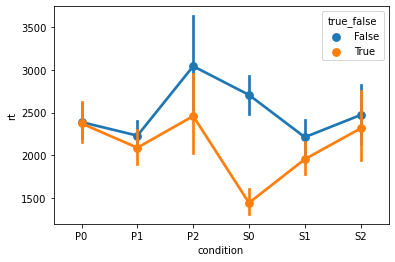

```python
sns.pointplot(data = df, x = 'condition', y = 'rt', hue = 'true_false')
```

```python
df.head()
```

|  | participantID | rt | true_false | condition | sentence | correct_response | response | correct |
| --- | --- | --- | --- | --- | --- | --- | --- | --- |
| 945 | 1637144464101 | 918 | True | P0 | Football has goals. | z | z | 1 |
| 62 | 1637220160839 | 2988 | True | P0 | A tugboat can pull. | z | z | 1 |
| 151 | 1637220153452 | 1150 | True | P0 | A canary can sing. | m | m | 1 |
| 173 | 1637220153452 | 1686 | True | P0 | A salmon is pink. | m | m | 1 |
| 74 | 1637220160839 | 1401 | False | P0 | A berry is large. | m | m | 1 |

Then we can separate our the P's from the S's:

```python
p_data = df.loc[((df['condition'] == 'P0') | (df['condition'] == 'P1') | (df['condition'] == 'P2'))]

s_data = df.loc[((df['condition'] == 'S0') | (df['condition'] == 'S1') | (df['condition'] == 'S2'))]
```

... and add a new column saying which category the data belong to:

```python
p_data['type'] = ['property']*p_data.shape[0]

level = []

for i in list(p_data['condition']):
    if i == 'P0':
        level.append('0')
    elif i == 'P1':
        level.append('1')
    elif i == 'P2':
        level.append('2')
p_data['level'] = level

s_data['type'] = ['superset']*s_data.shape[0]

level = []
for i in list(s_data['condition']):
    if i == 'S0':
        level.append('0')
    elif i == 'S1':
        level.append('1')
    elif i == 'S2':
        level.append('2')
s_data['level'] = level


# don't worry about the error messages.
```

```python
p_data
```

|  | participantID | rt | true_false | condition | sentence | correct_response | response | correct | type | level |
| --- | --- | --- | --- | --- | --- | --- | --- | --- | --- | --- |
| 945 | 1637144464101 | 918 | True | P0 | Football has goals. | z | z | 1 | property | 0 |
| 62 | 1637220160839 | 2988 | True | P0 | A tugboat can pull. | z | z | 1 | property | 0 |
| 151 | 1637220153452 | 1150 | True | P0 | A canary can sing. | m | m | 1 | property | 0 |
| 173 | 1637220153452 | 1686 | True | P0 | A salmon is pink. | m | m | 1 | property | 0 |
| 74 | 1637220160839 | 1401 | False | P0 | A berry is large. | m | m | 1 | property | 0 |
| ... | ... | ... | ... | ... | ... | ... | ... | ... | ... | ... |
| 158 | 1637220153452 | 770 | True | P2 | A lieutenant can talk. | m | m | 1 | property | 2 |
| 1594 | 1637144445325 | 2463 | False | P2 | A sycamore has fruit. | z | z | 1 | property | 2 |
| 283 | 1637220115644 | 1309 | True | P2 | A lieutenant can talk. | z | z | 1 | property | 2 |
| 1339 | 1637144479367 | 2578 | False | P2 | A brigade can fly. | z | z | 1 | property | 2 |
| 31 | 1637220160839 | 1847 | True | P2 | Gin is wet. | z | z | 1 | property | 2 |

799 rows × 10 columns

```python
s_data
```

|  | participantID | rt | true_false | condition | sentence | correct_response | response | correct | type | level |
| --- | --- | --- | --- | --- | --- | --- | --- | --- | --- | --- |
| 1850 | 1637144501002 | 1250 | True | S0 | A sardine is a sardine. | m | m | 1 | superset | 0 |
| 1889 | 1637144501002 | 2502 | False | S0 | A bass is a crab. | z | z | 1 | superset | 0 |
| 955 | 1637144464101 | 1016 | True | S0 | A sardine is a sardine. | z | z | 1 | superset | 0 |
| 1487 | 1637144466044 | 5167 | False | S0 | A raft is an aircraft carrier. | m | m | 1 | superset | 0 |
| 1488 | 1637144466044 | 1467 | True | S0 | A gardenia is a gardenia. | z | z | 1 | superset | 0 |
| ... | ... | ... | ... | ... | ... | ... | ... | ... | ... | ... |
| 549 | 1637220065369 | 2336 | True | S2 | A corporal is a person. | m | m | 1 | superset | 2 |
| 1262 | 1637144433406 | 1477 | False | S2 | A mesquite is a mineral. | m | m | 1 | superset | 2 |
| 19 | 1637220363788 | 2797 | False | S2 | A general is a monkey. | z | z | 1 | superset | 2 |
| 1634 | 1637144445325 | 1695 | False | S2 | Cognac is gas. | z | z | 1 | superset | 2 |
| 1243 | 1637144433406 | 2059 | False | S2 | Cognac is gas. | m | m | 1 | superset | 2 |

829 rows × 10 columns

Now that we have separted the conditions into two different columns ("type" and "level"), we can recombine our dataframes:

```python
df = pd.concat([p_data, s_data])
df.head()
```

|  | participantID | rt | true_false | condition | sentence | correct_response | response | correct | type | level |
| --- | --- | --- | --- | --- | --- | --- | --- | --- | --- | --- |
| 945 | 1637144464101 | 918 | True | P0 | Football has goals. | z | z | 1 | property | 0 |
| 62 | 1637220160839 | 2988 | True | P0 | A tugboat can pull. | z | z | 1 | property | 0 |
| 151 | 1637220153452 | 1150 | True | P0 | A canary can sing. | m | m | 1 | property | 0 |
| 173 | 1637220153452 | 1686 | True | P0 | A salmon is pink. | m | m | 1 | property | 0 |
| 74 | 1637220160839 | 1401 | False | P0 | A berry is large. | m | m | 1 | property | 0 |

and now we should be set up to run whatever analyses we want. E.g. we can plot our data in a more sensible way:

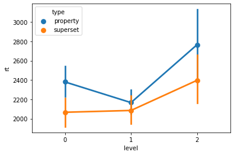

```python
sns.pointplot(data = df, x = 'level', y = 'rt', hue = 'type')
```

and run e.g. a 2-way repeated measures ANOVA:

```python
df.rm_anova(dv = 'rt', within = ['type', 'level'], subject = 'participantID')
```

|  | Source | SS | ddof1 | ddof2 | MS | F | p-unc | p-GG-corr | np2 | eps |
| --- | --- | --- | --- | --- | --- | --- | --- | --- | --- | --- |
| 0 | type | 3.018301e+06 | 1 | 21 | 3.018301e+06 | 9.154543 | 0.006433 | 0.006433 | 0.303588 | 1.000000 |
| 1 | level | 3.388259e+06 | 2 | 42 | 1.694129e+06 | 5.954282 | 0.005290 | 0.012488 | 0.220903 | 0.712147 |
| 2 | type * level | 5.157974e+05 | 2 | 42 | 2.578987e+05 | 1.134269 | 0.331312 | 0.322515 | 0.051245 | 0.795406 |

and, if we want, post-hoc t-tests:

```python
df.pairwise_ttests(dv = 'rt', within = ['type', 'level'], subject = 'participantID', padjust = 'holm')
```

|  | Contrast | type | A | B | Paired | Parametric | T | dof | alternative | p-unc | p-corr | p-adjust | BF10 | hedges |
| --- | --- | --- | --- | --- | --- | --- | --- | --- | --- | --- | --- | --- | --- | --- |
| 0 | type | - | property | superset | True | True | 3.025647 | 21.0 | two-sided | 0.006433 | NaN | NaN | 7.212 | 0.399038 |
| 1 | level | - | 0 | 1 | True | True | 1.333889 | 21.0 | two-sided | 0.196527 | 0.196527 | holm | 0.486 | 0.133477 |
| 2 | level | - | 0 | 2 | True | True | -2.189834 | 21.0 | two-sided | 0.039967 | 0.079933 | holm | 1.603 | -0.342255 |
| 3 | level | - | 1 | 2 | True | True | -2.870394 | 21.0 | two-sided | 0.009158 | 0.027473 | holm | 5.356 | -0.454705 |
| 4 | type * level | property | 0 | 1 | True | True | 2.032817 | 21.0 | two-sided | 0.054907 | 0.274533 | holm | 1.248 | 0.256657 |
| 5 | type * level | property | 0 | 2 | True | True | -1.722182 | 21.0 | two-sided | 0.099734 | 0.398937 | holm | 0.791 | -0.297740 |
| 6 | type * level | property | 1 | 2 | True | True | -3.003451 | 21.0 | two-sided | 0.006768 | 0.040609 | holm | 6.909 | -0.482924 |
| 7 | type * level | superset | 0 | 1 | True | True | -0.153712 | 21.0 | two-sided | 0.879305 | 0.879305 | holm | 0.225 | -0.023341 |
| 8 | type * level | superset | 0 | 2 | True | True | -1.549432 | 21.0 | two-sided | 0.136218 | 0.408654 | holm | 0.629 | -0.335036 |
| 9 | type * level | superset | 1 | 2 | True | True | -1.339964 | 21.0 | two-sided | 0.194577 | 0.408654 | holm | 0.489 | -0.303484 |

Amazing! A reasonable, interpretable result out of this mess!